# Peer Assessment II

I will now tune the model a bit, even if the model has been proposed via BMA model selection. I removed the Pool features, since those might be useless. The quality of the model will then be verified via Root Mean Squared Error on the test dataset.

```r
# Final model based on above Model Selection
Final.Model <- as.formula(price ~ Lot.Area +
                          MS.SubClass   + Overall.Qual +
                          Overall.Cond  + Year.Built +
                          Mas.Vnr.Type  + Mas.Vnr.Area +
                          Exter.Qual    + Exter.Cond +
                          Bsmt.Exposure + BsmtFin.SF.1 +
                          BsmtFin.SF.2  + Bsmt.Unf.SF +
                          X1st.Flr.SF   + X2nd.Flr.SF +
                          Bedroom.AbvGr + Kitchen.AbvGr +
                          Kitchen.Qual  + TotRms.AbvGrd +
                          Garage.Type   + Garage.Area +
                          Pool.Area     + Pool.QC +
                          Screen.Porch  + Sale.Condition)

# I removed the Pool features, since those might be useless

Final.Model.red <- as.formula(price ~ Lot.Area +
                          MS.SubClass   + Overall.Qual +
                          Overall.Cond  + Year.Built +
                          Mas.Vnr.Type  + Mas.Vnr.Area +
                          Exter.Qual    + Exter.Cond +
                          Bsmt.Exposure + BsmtFin.SF.1 +
                          BsmtFin.SF.2  + Bsmt.Unf.SF +
                          X1st.Flr.SF   + X2nd.Flr.SF +
                          Bedroom.AbvGr + Kitchen.AbvGr +
                          Kitchen.Qual  + TotRms.AbvGrd +
                          Garage.Type   + Garage.Area +
                          Screen.Porch  + Sale.Condition)
```

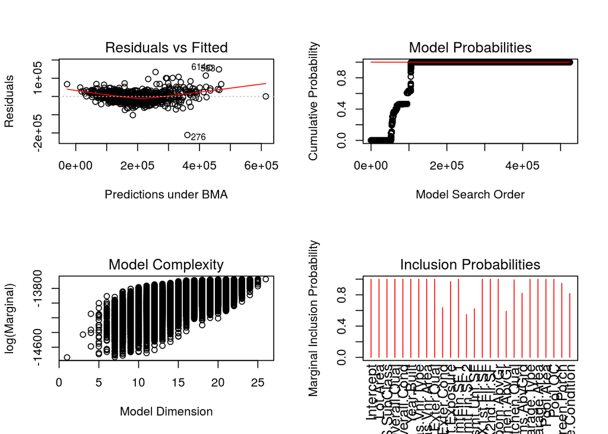

```r
model.BIC = bas.lm(Final.Model,
                    prior = "BIC",
                    modelprior = uniform(),
                    data = df.train)

model.BIC.red = bas.lm(Final.Model.red,
                    prior = "BIC",
                    modelprior = uniform(),
                    data = df.train)

par(mfrow = c(2, 2))
plot(model.BIC)
```

```r
predicted.BIC <- predict(model.BIC, df.test)
predicted.BIC.red <- predict(model.BIC.red, df.test)

rmse.bic <- rmse(df.test$price, predicted.BIC$Ybma)
rmse.bic.red <- rmse(df.test$price, predicted.BIC.red$Ybma)

RMSE <- data.frame(rbind(rmse.bic, rmse.bic.red))
colnames(RMSE) <- c('RMSE')

kable(RMSE[1:1], caption = 'RMSE')
```

RMSE

|  | RMSE |
| --- | --- |
| rmse.bic | 24576.48 |
| rmse.bic.red | 24248.23 |

Based on the calculated RMSE, I came to the following decision and therefore will continue with this model for further investigations:

**Decision on Final Model selection** **price ~ Lot.Area + MS.SubClass + Overall.Qual + Overall.Cond + Year.Built +** **Mas.Vnr.Type + Mas.Vnr.Area + Exter.Qual + Exter.Cond + Bsmt.Exposure + BsmtFin.SF.1 +BsmtFin.SF.2 + Bsmt.Unf.SF + X1st.Flr.SF + X2nd.Flr.SF + Bedroom.AbvGr +** **Kitchen.AbvGr + Kitchen.Qual + TotRms.AbvGrd + Garage.Type + Garage.Area + Screen.Porch + Sale.Condition**

**Coefficient Summaries** The summary outputs have been aggregated for convenience purposes. The section shows the marginal posterior mean, standard deviation and posterior inclusion probabilities obtained by BMA.

```r
model.bic.coef = coef(model.BIC.red)
interval   <- confint(model.bic.coef)
names <- c("post mean", "post sd", colnames(interval))
interval   <- cbind(model.bic.coef$postmean, model.bic.coef$postsd, interval)
colnames(interval) <- names
interval
```

```
                   post mean      post sd          2.5%         97.5%
Intercept       1.813552e+05 8.484683e+02  1.796793e+05  1.830068e+05
Lot.Area        5.791599e-01 9.519292e-02  3.933310e-01  7.672517e-01
MS.SubClass    -1.651065e+02 2.579088e+01 -2.143560e+02 -1.132792e+02
Overall.Qual    1.181696e+04 1.177394e+03  9.513498e+03  1.416796e+04
Overall.Cond    5.208245e+03 1.010443e+03  3.186052e+03  7.097590e+03
Year.Built      3.886788e+02 4.816540e+01  2.932305e+02  4.835545e+02
Mas.Vnr.Type   -4.489772e+03 8.457481e+02 -6.212069e+03 -2.888926e+03
Mas.Vnr.Area    5.346675e+01 6.974251e+00  3.964323e+01  6.707440e+01
Exter.Qual      1.719269e+04 2.654807e+03  1.215788e+04  2.264671e+04
Exter.Cond     -3.293361e+03 3.704063e+03 -9.860986e+03  0.000000e+00
Bsmt.Exposure   3.188984e+03 9.373899e+02  1.393811e+03  5.013229e+03
BsmtFin.SF.1    3.535424e+01 6.443486e+00  2.558990e+01  4.758728e+01
BsmtFin.SF.2    6.031375e+00 9.114529e+00  0.000000e+00  2.450423e+01
Bsmt.Unf.SF     6.656691e+00 7.023470e+00 -2.613049e-03  1.877117e+01
X1st.Flr.SF     7.287538e+01 7.102049e+00  5.913100e+01  8.615211e+01
X2nd.Flr.SF     6.152679e+01 4.860213e+00  5.216448e+01  7.085968e+01
Bedroom.AbvGr  -1.082636e+04 1.780496e+03 -1.429671e+04 -7.403523e+03
Kitchen.AbvGr  -3.663300e+03 6.575063e+03 -1.880630e+04  0.000000e+00
Kitchen.Qual    8.288678e+03 2.246426e+03  3.927905e+03  1.253306e+04
TotRms.AbvGrd   1.810178e+03 1.816444e+03  0.000000e+00  4.831360e+03
Garage.Type    -3.149669e+03 6.993871e+02 -4.575536e+03 -1.833163e+03
Garage.Area     2.669498e+01 5.501972e+00  1.584999e+01  3.740638e+01
Screen.Porch    5.817609e+01 1.889102e+01  2.231508e+01  9.666627e+01
Sale.Condition -9.125483e+03 5.521662e+03 -1.696051e+04  0.000000e+00
                        beta
Intercept       1.813552e+05
Lot.Area        5.791599e-01
MS.SubClass    -1.651065e+02
Overall.Qual    1.181696e+04
Overall.Cond    5.208245e+03
Year.Built      3.886788e+02
Mas.Vnr.Type   -4.489772e+03
Mas.Vnr.Area    5.346675e+01
Exter.Qual      1.719269e+04
Exter.Cond     -3.293361e+03
Bsmt.Exposure   3.188984e+03
BsmtFin.SF.1    3.535424e+01
BsmtFin.SF.2    6.031375e+00
Bsmt.Unf.SF     6.656691e+00
X1st.Flr.SF     7.287538e+01
X2nd.Flr.SF     6.152679e+01
Bedroom.AbvGr  -1.082636e+04
Kitchen.AbvGr  -3.663300e+03
Kitchen.Qual    8.288678e+03
TotRms.AbvGrd   1.810178e+03
Garage.Type    -3.149669e+03
Garage.Area     2.669498e+01
Screen.Porch    5.817609e+01
Sale.Condition -9.125483e+03
```

### 2.3.2 Section 3.2 Transformation

In the previous section we defined the Final Model, which we will use to apply transformations on certain features. We saw earlier that the data indicates a non linearity, as well as features not being normal distributed. This are the points we need to address.

The Residuals plot from section 2.3 indicated clearly a non linearity of the data. Non linearity can be compensated by applying quadratic, log or root transformation to the model.

RMSE on test data

|  | RMSE |
| --- | --- |
| rmse.bic.base | 24242.59 |
| rmse.bic.sqr | 22331.66 |
| rmse.bic.sqr_log | 19327.35 |

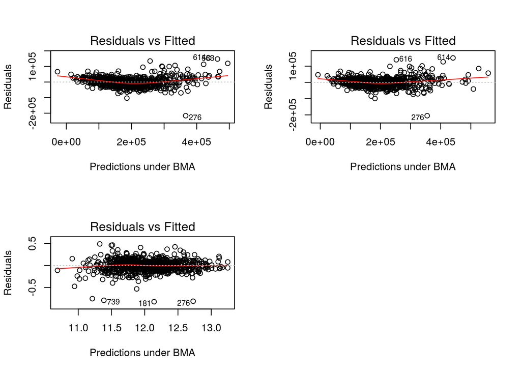

```r
df.train <- df.train.NoOutliner

# Model Selection without transformation
Final.Model.base <- as.formula(price ~ Lot.Area +
                                 MS.SubClass   + Overall.Qual +
                                 Overall.Cond  + Year.Built +
                                 Mas.Vnr.Type  + Mas.Vnr.Area +
                                 Exter.Qual    + Exter.Cond +
                                 Bsmt.Exposure + BsmtFin.SF.1 +
                                 BsmtFin.SF.2  + Bsmt.Unf.SF +
                                 X1st.Flr.SF   + X2nd.Flr.SF +
                                 Bedroom.AbvGr + Kitchen.AbvGr +
                                 Kitchen.Qual  + TotRms.AbvGrd +
                                 Garage.Type   + Garage.Area +
                                 Screen.Porch  + Sale.Condition)

# Model Selection with squared parameter transformation
Final.Model.sqr <- as.formula(price ~
                            Lot.Area      + I(Lot.Area^2) +
                            MS.SubClass   + I(MS.SubClass^2) +
                            Overall.Qual  + Overall.Cond +
                            Year.Built    + Mas.Vnr.Type +
                            Mas.Vnr.Area  + I(Mas.Vnr.Area^2) +
                            Exter.Qual    + Exter.Cond    +
                            Bsmt.Exposure +
                            BsmtFin.SF.1  + I(BsmtFin.SF.1^2) +
                            BsmtFin.SF.2  + I(BsmtFin.SF.2^2) +
                            Bsmt.Unf.SF   +
                            X1st.Flr.SF   + I(X1st.Flr.SF^2) +
                            X2nd.Flr.SF   + I(X2nd.Flr.SF^2) +
                            Bedroom.AbvGr + I(Bedroom.AbvGr^2) +
                            Kitchen.AbvGr +
                            Kitchen.Qual  + TotRms.AbvGrd +
                            Garage.Type   + Garage.Area +
                            Screen.Porch  + I(Screen.Porch^2) +
                            Sale.Condition)

# Model Selection with squared- and log transformed parameters
Final.Model.Sqr_and_Log <- as.formula(log(price) ~
                            log(Lot.Area) + I(Lot.Area^2) +
                            MS.SubClass   + I(MS.SubClass^2) +
                            Overall.Qual  + Overall.Cond +
                            Year.Built    + Mas.Vnr.Type +
                            Mas.Vnr.Area  + I(Mas.Vnr.Area^2) +
                            Exter.Qual    + Exter.Cond    +
                            Bsmt.Exposure +
                            BsmtFin.SF.1  + I(BsmtFin.SF.1^2) +
                            BsmtFin.SF.2  + I(BsmtFin.SF.2^2) +
                            Bsmt.Unf.SF   +
                            X1st.Flr.SF   + I(X1st.Flr.SF^2) +
                            X2nd.Flr.SF   + I(X2nd.Flr.SF^2) +
                            Bedroom.AbvGr + I(Bedroom.AbvGr^2) +
                            Kitchen.AbvGr +
                            Kitchen.Qual  + TotRms.AbvGrd +
                            Garage.Type   + Garage.Area +
                            Screen.Porch  + I(Screen.Porch^2) +
                            Sale.Condition)

# Bayesian Model Averaging
# on the final base model
model.bic.base =  bas.lm(Final.Model.base,
                         df.train,
                         prior="BIC",
                         modelprior=uniform(),
                         method = "MCMC",
                         MCMC.iterations = 10^6)

# Bayesian Model Averaging
# on the final squared model
model.bic.sqr =  bas.lm(Final.Model.sqr,
                        df.train,
                        prior="BIC",
                        modelprior=uniform(),
                        method = "MCMC",
                        MCMC.iterations = 10^6)

# Bayesian Model Averaging
# on the final squared and log transformed model
model.bic.sqr_log =  bas.lm(Final.Model.Sqr_and_Log,
                   df.train,
                   prior="BIC",
                   modelprior=uniform(),
                   method = "MCMC",
                   MCMC.iterations = 10^6)

par(mfrow = c(2, 2))
plot(model.bic.base, which = 1)
plot(model.bic.sqr, which = 1)
plot(model.bic.sqr_log, which = 1)

predicted.bic.base    <- predict(model.bic.base, df.test)
predicted.bic.sqr     <- predict(model.bic.sqr, df.test)
predicted.bic.sqr_log <- predict(model.bic.sqr_log, df.test)

prediction <- data.frame(cbind( predicted.bic.base$Ybma, predicted.bic.sqr$Ybma, predicted.bic.sqr_log$Ybma))
prediction <- cbind(prediction, df.test$price)
names(prediction) <- c( 'Base', 'SQR', 'SQL LOG', 'Price')

rmse.bic.base <- rmse(df.test$price, predicted.bic.base$Ybma)
rmse.bic.sqr <- rmse(df.test$price, predicted.bic.sqr$Ybma)
rmse.bic.sqr_log <- rmse(df.test$price, exp(predicted.bic.sqr_log$Ybma))

RMSE <- data.frame(rbind(rmse.bic.base, rmse.bic.sqr, rmse.bic.sqr_log))
colnames(RMSE) <- c('RMSE')

kable(RMSE[1:1], caption = 'RMSE on test data')
```

The graph above shows 3 plots. Plot 1 only uses the plain formula. Plot 2 has some quadratic elements attached, while plot 3 uses quadratic as well as logarithmic elements. These three residual plots show clearly how the regression line levels out (from bow shaped to a straight line) by using quadratic or logarithmic and quadratic functions.

### 2.3.3 Section 3.3 Variable Interaction

We now will investigate if we need to apply any interaction variables. For that purpose we will investigate on how much multicollinearity (correlation between predictors) exists in our regression model via Variance inflation factors (VIF). Multicollinearity is problematic because it can increase the variance of the regression coefficients, making them unstable and difficult to interpret. Variance inflation factors (VIF) measure how much the variance of the estimated regression coefficients are inflated as compared to when the predictor variables are not linearly related.

```r
df.train <- df.train.NoOutliner

Final.Model.base <- as.formula(price ~ Lot.Area +
                                 MS.SubClass   + Overall.Qual +
                                 Overall.Cond  + Year.Built +
                                 Mas.Vnr.Type  + Mas.Vnr.Area +
                                 Exter.Qual    + Exter.Cond +
                                 Bsmt.Exposure + BsmtFin.SF.1 +
                                 BsmtFin.SF.2  + Bsmt.Unf.SF +
                                 X1st.Flr.SF   + X2nd.Flr.SF +
                                 Bedroom.AbvGr + Kitchen.AbvGr +
                                 Kitchen.Qual  + TotRms.AbvGrd +
                                 Garage.Type   + Garage.Area +
                                 Screen.Porch  + Sale.Condition)

vif(lm(Final.Model.base, df.train))
```

```
      Lot.Area    MS.SubClass   Overall.Qual   Overall.Cond     Year.Built
      1.197906       1.503877       3.622547       1.455916       2.753765
  Mas.Vnr.Type   Mas.Vnr.Area     Exter.Qual     Exter.Cond  Bsmt.Exposure
      1.918035       2.241271       3.162982       1.191252       1.304135
  BsmtFin.SF.1   BsmtFin.SF.2    Bsmt.Unf.SF    X1st.Flr.SF    X2nd.Flr.SF
      4.920668       1.571143       4.427113       5.745823       4.092895
 Bedroom.AbvGr  Kitchen.AbvGr   Kitchen.Qual  TotRms.AbvGrd    Garage.Type
      2.477266       1.620652       2.570608       4.452934       1.637755
   Garage.Area   Screen.Porch Sale.Condition
      1.980269       1.052840       1.039249
```

The figures above indicates that all of our features are moderately correlated. Therefore, we decide **not to include any variable interactions**.

### 2.3.4 Section 3.4 Variable Selection

I went through various steps to identify the final model. The method used is just one part of the story. Feature engineering, cleaning and recoding of the data is one of the major tasks on the route to select the best model. Having finalized the cleaning, I used multiple approaches to select the final model. The approaches are listed below:

1-Feature engineering 2-Model Selection 2-1) Bayesian Model Averaging (Bayesian Information Criterion) 2-2) Akaike information criterion (AIC) 2-3) Removed some features 3-Model Tuning 3-1) Apply quadratic / log transformation 4-Model validation Each used approach came out with a different **best** model. So we needed compare the different models to finally identify the best model.

The final Model is the following:

**log(price) ~ log(Lot.Area) + I(Lot.Area^2) + MS.SubClass + I(MS.SubClass^2) +** **Overall.Qual + Overall.Cond + Year.Built + Mas.Vnr.Type + Mas.Vnr.Area +** **I(Mas.Vnr.Area^2) + Exter.Qual + Exter.Cond + Bsmt.Exposure + BsmtFin.SF.1 +** **I(BsmtFin.SF.1^2) + BsmtFin.SF.2 + I(BsmtFin.SF.2^2) + Bsmt.Unf.SF + X1st.Flr.SF +** **I(X1st.Flr.SF^2) + X2nd.Flr.SF + I(X2nd.Flr.SF^2) +** **Bedroom.AbvGr + I(Bedroom.AbvGr^2) + Kitchen.AbvGr + Kitchen.Qual + TotRms.AbvGrd +** **Garage.Type + Garage.Area + Screen.Porch + I(Screen.Porch^2) + Sale.Condition**

### 2.3.5 Section 3.5 Model Testing

The parsimonious model proposed in section 3.1 Final Model was used as initial model to run initial predictions on the test data set. The comparison of the RMSE by using both training- and test data, while predicting house prices indicated that the model was not overfitting.

The evaluation on the model has mainly been performed via the **Root Mean Squared Error**.

## 2.4 Part 4 Final Model Assessment

### 2.4.1 Section 4.1 Final Model Residual

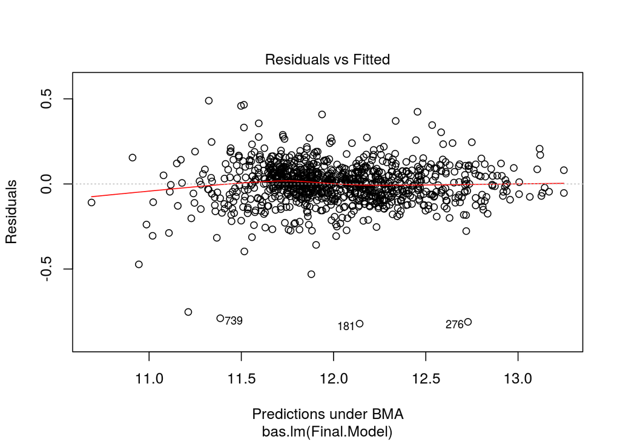

```r
df.train <- df.train.NoOutliner

# Model Selection with squared and log transformation
Final.Model <- as.formula(log(price) ~
                            log(Lot.Area) + I(Lot.Area^2) +
                            MS.SubClass   + I(MS.SubClass^2) +
                            Overall.Qual  + Overall.Cond +
                            Year.Built    + Mas.Vnr.Type +
                            Mas.Vnr.Area  + I(Mas.Vnr.Area^2) +
                            Exter.Qual    + Exter.Cond    +
                            Bsmt.Exposure +
                            BsmtFin.SF.1  + I(BsmtFin.SF.1^2) +
                            BsmtFin.SF.2  + I(BsmtFin.SF.2^2) +
                            Bsmt.Unf.SF   +
                            X1st.Flr.SF   + I(X1st.Flr.SF^2) +
                            X2nd.Flr.SF   + I(X2nd.Flr.SF^2) +
                            Bedroom.AbvGr + I(Bedroom.AbvGr^2) +
                            Kitchen.AbvGr +
                            Kitchen.Qual  + TotRms.AbvGrd +
                            Garage.Type   + Garage.Area +
                            Screen.Porch  + I(Screen.Porch^2) +
                            Sale.Condition)

# Bayesian Model Averaging
# on the final model
model.bic =  bas.lm(Final.Model,
                        df.train,
                        prior="BIC",
                        modelprior=uniform(),
                        method = "MCMC",
                        MCMC.iterations = 10^6)

plot(model.bic, which = 1)
```

The plot has been shown already in section 3.2, where we investigated on the feature transformation. As one can see, the residuals plot shows a nearly straight regression line, which means that we were able to compensate the non linearity of our data. So far we managed to establish a decent model by introducing quadratic and log transformed features. There is certainly still potential in optimizing our model, by optimizing the strategy for using NA values or creating new features.

### 2.4.2 Section 4.2 Final Model RMSE

We will now calculate the Root Mean Squared Error (RMSE) of our final model on the test dataset.

```r
df.train <- df.train.NoOutliner

# Model Selection with squared and log transformation
Final.Model <- as.formula(log(price) ~
                            log(Lot.Area) + I(Lot.Area^2) +
                            MS.SubClass   + I(MS.SubClass^2) +
                            Overall.Qual  + Overall.Cond +
                            Year.Built    + Mas.Vnr.Type +
                            Mas.Vnr.Area  + I(Mas.Vnr.Area^2) +
                            Exter.Qual    + Exter.Cond    +
                            Bsmt.Exposure +
                            BsmtFin.SF.1  + I(BsmtFin.SF.1^2) +
                            BsmtFin.SF.2  + I(BsmtFin.SF.2^2) +
                            Bsmt.Unf.SF   +
                            X1st.Flr.SF   + I(X1st.Flr.SF^2) +
                            X2nd.Flr.SF   + I(X2nd.Flr.SF^2) +
                            Bedroom.AbvGr + I(Bedroom.AbvGr^2) +
                            Kitchen.AbvGr +
                            Kitchen.Qual  + TotRms.AbvGrd +
                            Garage.Type   + Garage.Area +
                            Screen.Porch  + I(Screen.Porch^2) +
                            Sale.Condition)

# Bayesian Model Averaging
# on the final model
final.model.bic =  bas.lm(Final.Model,
                   df.train,
                   prior="BIC",
                   modelprior=uniform(),
                   method = "MCMC",
                   MCMC.iterations = 10^6)

predicted.bic.final    <- predict(final.model.bic, df.test)
rmse.bic <- rmse(df.test$price, exp(predicted.bic.final$Ybma))

RMSE <- data.frame(rbind(rmse.bic))
colnames(RMSE) <- c('RMSE')

kable(RMSE[1:1], caption = 'RMSE on Test data')
```

RMSE on Test data

|  | RMSE |
| --- | --- |
| rmse.bic | 19335.63 |

### 2.4.3 Section 4.3 Final Model Evaluation

**Strengths of the final model** 1- I spent quite some time for the feature engineering part. Applied some cleaning of outliners and high leverage points (Cook distance). But it finally proved to be helpful to get a more robust model. 2-Model Selection has been performed towards the parsimonious model. The model with the lowest number of features has been used. But I also went a step further to remove certain features to reduce the model complexity. 3-Multicollinearity has been avoided by verifying features via Variance inflation factors. 4-Feature transformation has been applied to compensate the non linearity of the model 5-The model properly reflect uncertainty confirmed by determining the coverage probability and the true value of price that fall within the 95% prediction confidence interval is 97% 6-The final model has proofed to have the smallest RMSE during real life (validation) tests. The lower the RMSE the better the model.

**Weaknesses of Final Model** 1-Although I invested a lot of time in feature engineering, there is a lot more to get out of it. Especially the strategy of filling the missing data. One can apply a more sophisticated approach then I did. 2-Features, which are available could be clustered to be more informative (e.g. Sale Condition - Normal and Not normal) 3-I also believe there are some features, which I reckon have some relevance, but could not proof it (combination of features)

### 2.4.4 Section 4.4 Final Model Validation

Testing our final model on a separate, validation data set is a great way to determine how our model will perform in real-life practice.

**Visual interpretation of Residuals, Leverage and Q-Q plot**

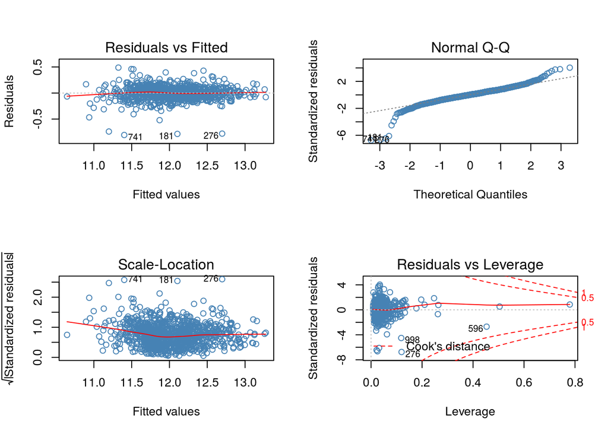

```r
df.train <- df.train.NoOutliner

# Model Selection
Final.Model <- as.formula(log(price) ~
                            log(Lot.Area) + I(Lot.Area^2) +
                            MS.SubClass   + I(MS.SubClass^2) +
                            Overall.Qual  + Overall.Cond +
                            Year.Built    + Mas.Vnr.Type +
                            Mas.Vnr.Area  + I(Mas.Vnr.Area^2) +
                            Exter.Qual    + Exter.Cond    +
                            Bsmt.Exposure +
                            BsmtFin.SF.1  + I(BsmtFin.SF.1^2) +
                            BsmtFin.SF.2  + I(BsmtFin.SF.2^2) +
                            Bsmt.Unf.SF   +
                            X1st.Flr.SF   + I(X1st.Flr.SF^2) +
                            X2nd.Flr.SF   + I(X2nd.Flr.SF^2) +
                            Bedroom.AbvGr + I(Bedroom.AbvGr^2) +
                            Kitchen.AbvGr +
                            Kitchen.Qual  + TotRms.AbvGrd +
                            Garage.Type   + Garage.Area +
                            Screen.Porch  + I(Screen.Porch^2) +
                            Sale.Condition)

model.lm <- lm(Final.Model, df.train)

par(mfrow = c(2, 2))
plot(model.lm, col = 'steelblue')
```

Consulting the plots above again, we see that the **Residual vs. Fitted** plot shows almost a straight line. A Q-Q plot is a scatterplot created by plotting two sets of quantiles against one another. If both sets of quantiles came from the same distribution, we should see the points forming a line that’s roughly straight. This is not entirely for our distribution. Therefore, our model still shows improvement potential. If we look at the **Residuals vs Leverage**, which provides a visual interpretation of high leverage points via the Cook’s distance, we see that all our data points lay within the boundaries.

**Comparing RMSE with training-, test and validation data applied**

```r
# Predict and calculate RMSE on training data
predicted.train <- predict(model.lm, df.train)
RMSE.train <- rmse(df.train$price, exp(predicted.train))

# Predict and calculate RMSE on test data
predicted.test <- predict(model.lm, df.test)
RMSE.test <- rmse(df.test$price, exp(predicted.test))

# Predict and calculate RMSE on validation data
predicted.validation <- predict(model.lm, df.validation)
RMSE.validation <- rmse(df.validation$price, exp(predicted.validation))

RMSE <- data.frame(rbind(RMSE.train, RMSE.test, RMSE.validation))
colnames(RMSE) <- c('RMSE')
kable(RMSE[1:1], caption = 'RMSE')
```

RMSE

|  | RMSE |
| --- | --- |
| RMSE.train | 21810.61 |
| RMSE.test | 18630.00 |
| RMSE.validation | 18817.73 |

The final model evaluation states a quite nice picture as you can see from the table above. The Root Mean Squared Error (RMSE), which is at around **21’810** dollar, while calculating the RMSE based on training data. The RMSE slightly drops With the test data (dollar - 18’630), but using the real-life (validation) data, our model shows slight rise of the RMSE (dollar - 18’817). In general, the lower the RMSE, the better the model fit. Therefore, our final model is a better fitted for validation data.

**Under- and Overvalued houses** Which houses will be Under- and Overvalued by our model. To answer this question we need to have a look at the Residuals vs Fitted plot. The plot can be separated into 2 areas - lower 25% and medium to higher (75%) sections. Houses in the lower price segment (25%) will slightly be over valued. This is obvious, since we have a slight non linearity in this area. Housing prices in the mid and high range should be pretty precise, since we have almost a straight regression line.

**Coverage of true values**

```r
final.prediction <- predict(model.lm, df.validation, interval = "prediction", level = 0.95)
coverage <- mean(df.validation$price > exp(final.prediction[,"lwr"]) & df.validation$price < exp(final.prediction[,"upr"]))
coverage
```

```
[1] 0.9750329
```

The uncertainty respectively the coverage has been calculated, to assess if the we met the 95% confidence interval containing the true value of the houses. The calculation of the 95% confidence interval reveals that the true value of housing prices is met in around 97% of the cases. That means, this final model properly reflects the uncertainty.

## 2.5 Part 5 Conclusion

The data set at hand was used to gather deep insight on the key characteristics that can influence sales prices of a homes in Ames, Iowa. The stepwise approach in analysing data thoroughly, deriving information from it towards data transformation to reach a decent result at the end, is quite a journey. Feature engineering, cleaning and recoding of the data proofed to be one of the major tasks on the route to select the best model. I also experienced that this is one of the most time consuming parts in designing a model. The Model selection process by using multiple approaches gave me a deep insight in the diverse selection methods. To me it was helpful to start with an initial model to get a feeling, respectively get a reference point to start with. Constantly measuring the improvement of the model via **adjusted R22, Root Mean Squared Error** or visual representations as **Residual vs. Fitted** plots is vital to understand the behaviour of each change on the model. There was one ‘aha’ effect I had, when I went into investigating the impact of outliners and high leverage points. Removing 2 outliners from the whole data set changed the initial parsimonious model to a new parsimonious model. I didn’t expect 2 data points having such an impact. My fundamental learning in this assessment was that getting the best model wasn’t primarily driven by the model I used. It was rather driven by managing outliners, high leverage points, feature engineering and transformation. In those areas lies the real potential to get a good model. Following a stepwise approach (improving and constantly measuring) by using the mentioned approaches in cooperation with the Bayesian Model Averaging approach, we were able to find a robust model. If we compare where we started off with the initial model (RMSE: 34’971 Dollars - on training data) and where we ended (RMSE: 18’630 dollars on test data and 18’817 dollars on validation data), we were able to improve our model by close to 50%. It was a tremendous journey which gave me lots of learnings.

## 2.6 Appendix

**Helper Functions**

The following functions were produced to fullfill certain recurring tasks, which have been used during this assessment.

```r
# An NA value usually means that there is no object. So if it is a numerical
# variable we set the NA values to 0.
# Features (caracter variables) as Quality, Condition etc. often indicate items with an NA value if
# such an object doesn't exist, so we replace the NA values by 'none'
#
# We also recode ordered factors as pseudo-continuous numerical variables
#
# Params: df    - data set to convert
#
# Return: df    - converted dataset
NaHandler <- function( df ){

  df <- data.frame(df)

  # Initiall we do it the easy way.
  # An NA value usually means that there is no object, so we set the NA values to 0

  df <- df %>% mutate(Garage.Cars    = ifelse(is.na(Garage.Cars), 0, Garage.Cars))
  df <- df %>% mutate(Garage.Area    = ifelse(is.na(Garage.Area), 0, Garage.Area))
  df <- df %>% mutate(Bsmt.Full.Bath = ifelse(is.na(Bsmt.Full.Bath), 0, Bsmt.Full.Bath))
  df <- df %>% mutate(Bsmt.Half.Bath = ifelse(is.na(Bsmt.Half.Bath), 0, Bsmt.Half.Bath))
  df <- df %>% mutate(BsmtFin.SF.1   = ifelse(is.na(BsmtFin.SF.1), 0, BsmtFin.SF.1))
  df <- df %>% mutate(BsmtFin.SF.2   = ifelse(is.na(BsmtFin.SF.2), 0, BsmtFin.SF.2))
  df <- df %>% mutate(Bsmt.Unf.SF    = ifelse(is.na(Bsmt.Unf.SF), 0, Bsmt.Unf.SF))
  df <- df %>% mutate(Total.Bsmt.SF  = ifelse(is.na(Total.Bsmt.SF), 0, Total.Bsmt.SF))

  df <- df %>% mutate(Lot.Frontage   = ifelse(is.na(Lot.Frontage), 0, Lot.Frontage))
  df <- df %>% mutate(Garage.Yr.Blt  = ifelse(is.na(Garage.Yr.Blt), 0, Garage.Yr.Blt))
  df <- df %>% mutate(Mas.Vnr.Area   = ifelse(is.na(Mas.Vnr.Area), 0, Mas.Vnr.Area))

  # The features like Quality, Condition etc. often indicate items with an NA value if
  # such an object doesn't exist, so we replace the NA values to 'none'

  # Recode ordered factors as pseudo-continuous numerical variables
  df$Bsmt.Qual      <- recode(df$Bsmt.Qual, 'none')
  df$Bsmt.Cond      <- recode(df$Bsmt.Cond, 'none')
  df$Fireplace.Qu   <- recode( df$Fireplace.Qu, 'none' )
  df$Pool.QC        <- recode( df$Pool.QC, 'none' )
  df$Bsmt.Qual      <- recode( df$Bsmt.Qual, 'none' )
  df$Bsmt.Cond      <- recode( df$Bsmt.Cond, 'none' )
  df$Bsmt.Exposure  <- recode( df$Bsmt.Exposure, 'none')
  df$BsmtFin.Type.1 <- recode( df$BsmtFin.Type.1, 'none')
  df$BsmtFin.Type.2 <- recode( df$BsmtFin.Type.2, 'none' )
  df$Fence          <- recode( df$Fence, 'none' )
  df$Alley          <- recode( df$Alley, 'none' )
  df$Garage.Type    <- recode( df$Garage.Type, 'none' )
  df$Garage.Qual    <- recode( df$Garage.Qual, 'none' )
  df$Garage.Finish  <- recode( df$Garage.Finish, 'none' )
  df$Garage.Cond    <- recode( df$Garage.Cond, 'none' )
  df$Misc.Feature   <- recode( df$Misc.Feature, 'none' )
  df$Mas.Vnr.Type   <- recode( df$Mas.Vnr.Type, 'None' ) # 29

 # TODO
 # Year Built

  return(df)
}
```

```r
# Map features to numerical values
#
# Params: df    - data set to convert
#
# Return: df    - converted dataset
recode.features <- function(df){

  # Map features to numerical values
  feature.list = c('Exter.Qual', 'Exter.Cond', 'Garage.Qual', 'Garage.Cond',
                   'Fireplace.Qu', 'Kitchen.Qual', 'Heating.QC', 'Bsmt.Qual',
                   'Bsmt.Cond', 'Pool.QC' )
  param.list = c('none' = 0, 'Po' = 1, 'Fa' = 2, 'TA' = 3, 'Gd' = 4, 'Ex' = 5)
  df <- map.fcn(feature.list, param.list, df)

  param.list = c('none' = 0, 'No' = 1, 'Mn' = 2, 'Av' = 3, 'Gd' = 4)
  data.train <- map.fcn(c('Bsmt.Exposure'), param.list, df)

  feature.list = c('BsmtFin.Type.1','BsmtFin.Type.2')
  param.list = c('none' = 0, 'Unf' = 1, 'LwQ' = 2,'Rec'= 3, 'BLQ' = 4,
                 'ALQ' = 5, 'GLQ' = 6)
  df = map.fcn(feature.list, param.list, df)

  param.list = c('None' = 0, 'Sal' = 1, 'Sev' = 2, 'Maj2' = 3, 'Maj1' = 4,
                 'Mod' = 5, 'Min2' = 6, 'Min1' = 7, 'Typ'= 8)
  df = map.fcn(c('Functional'), param.list, df)

  param.list = c('none' = 0,'Unf' = 1, 'RFn' = 2, 'Fin' = 3)
  df = map.fcn(c('Garage.Finish'), param.list, df)

  param.list = c('none' = 0, 'MnWw' = 1, 'GdWo' = 2, 'MnPrv' = 3,
                 'GdPrv' = 4)
  df = map.fcn(c('Fence'), param.list, df)

  param.list = c('none' = 0, 'Shed' = 1, 'Othr' = 2, 'Gar2' = 3,
                 'Elev' = 4, 'TenC' = 5)
  df = map.fcn(c('Misc.Feature'), param.list, df)

  param.list = c('none' = 0, 'CarPort' = 1, 'Detchd' = 2, 'BuiltIn' = 3,
                 'Basment' = 4, 'Attchd' = 5, '2Types' = 6)
  df = map.fcn(c('Garage.Type'), param.list, df)

  param.list = c('None' = 0, 'Stone' = 1, 'CBlock' = 2, 'BrkFace' = 3,
                 'BrkCmn' = 4)
  df = map.fcn(c('Mas.Vnr.Type'), param.list, df)

  param.list = c('none' = 0, 'Grvl' = 1, 'Pave' = 2)
  df = map.fcn(c('Alley'), param.list, df)

  param.list = c('none' = 0, 'ELO' = 1, 'NoSewr' = 2, 'NoSeWa' = 3,
                 'AllPub' = 4)
  df = map.fcn(c('Utilities'), param.list, df)

  param.list = c('none' = 1, 'N' = 1, 'P' = 2, 'Y' = 3)
  df = map.fcn(c('Paved.Drive'), param.list, df)

  param.list = c('none' = 0, 'N' = 0,'Y' = 1)
  df = map.fcn(c('Central.Air'), param.list, df)

  param.list = c('none' = 1, 'Grvl' = 1,'Pave' = 2)
  df = map.fcn(c('Street'), param.list, df)

  param.list = c('none' = 0, 'No' = 1, 'Mn' = 2, 'Gd' = 3, 'Av' = 4)
  df = map.fcn(c('Bsmt.Exposure'), param.list, df)

  param.list = c('none' = 1, 'Inside' = 1, 'Corner' = 2, 'CulDSac' = 3,
                 'CulDSac' = 4, 'FR2' = 5, 'FR3' = 6)
  df = map.fcn(c('Lot.Config'), param.list, df)

  param.list = c('none' = 1, 'A (all)' = 1, 'C (all)' = 2, 'RM' = 3, 'FV' = 4,
                 'RH' = 5, 'RP' = 6, 'I (all)' = 7, 'RL' = 8)
  df = map.fcn(c('MS.Zoning'), param.list, df)

  param.list = c('none' = 1, 'Gtl' = 1, 'Mod' = 2, 'Sev' = 3)
  df = map.fcn(c('Land.Slope'), param.list, df)

  param.list = c('none' = 1, 'Reg' = 1, 'IR1' = 2, 'IR2' = 3, 'IR3' = 4)
  df = map.fcn(c('Lot.Shape'), param.list, df)

  param.list = c('none' = 1, 'Lvl' = 1, 'Low' = 2, 'HLS' = 3, 'Bnk' = 4)
  df = map.fcn(c('Land.Contour'), param.list, df)

  param.list = c('none' = 1, 'Normal' = 1, 'Partial' = 2, 'AdjLand' = 3,
                 'Abnorml' = 4, 'Alloca' = 5, 'Family' = 6)
  df = map.fcn(c('Sale.Condition'), param.list, df)

  param.list = c('none' = 10, 'COD' = 1, 'Con' = 2, 'ConLD' = 3, 'ConLI' = 4,
                 'ConLw' = 5, 'CWD' = 6, 'New' = 7, 'Oth' = 8, 'VWD' = 9, 'WD ' = 10)
  df = map.fcn(c('Sale.Type'), param.list, df)

  param.list = c('none' = 5, 'FuseA' = 1, 'FuseF' = 2, 'FuseP' = 3, 'Mix' = 4,
                 'SBrkr' = 5)
  df = map.fcn(c('Electrical'), param.list, df)

  param.list = c('none' = 2, 'Floor' = 1, 'GasA' = 2, 'GasW' = 3, 'Grav' = 4,
                 'OthW' = 5, 'Wall' = 6 )
  df = map.fcn(c('Heating'), param.list, df)

  param.list = c('none' = 3, 'BrkTil' = 1, 'CBlock' = 2, 'PConc' = 3, 'Slab' = 4,
                 'Stone' = 5, 'Wood' = 6 )
  df = map.fcn(c('Foundation'), param.list, df)

  param.list = c('none' = 15, 'AsbShng' = 1, 'AsphShn' = 2, 'BrkComm' = 3,
                 'BrkFace' = 4, 'CBlock' = 5, 'CemntBd' = 6, 'HdBoard' = 7,
                 'ImStucc' = 8, 'MetalSd' = 9, 'Other' = 10, 'Plywood' = 11,
                 'PreCast' = 12, 'Stone' = 13, 'Stucco' = 14, 'VinylSd' = 15,
                 'Wd Sdng' = 16, 'WdShing' = 17, 'Wd Shng' = 18)
  df <- map.fcn('Exterior.1st', param.list, df)

  param.list = c('none' = 15, 'AsbShng' = 1, 'AsphShn' = 2, 'Brk Cmn' = 3,
                 'BrkFace' = 4, 'CBlock' = 5, 'CmentBd' = 6, 'HdBoard' = 7,
                 'ImStucc' = 8, 'MetalSd' = 9, 'Other' = 10, 'Plywood' = 11,
                 'PreCast' = 12, 'Stone' = 13, 'Stucco' = 14, 'VinylSd' = 15,
                 'Wd Sdng' = 16, 'Wd Shng' = 17
  )
  df <- map.fcn('Exterior.2nd', param.list, df)

  feature.list = c('Condition.1', 'Condition.2')
  param.list = c('none' = 3, 'Artery' = 1, 'Feedr' = 2, 'Norm' = 3, 'RRNn' = 4,
                 'RRAn' = 5, 'PosN' = 6, 'PosA' = 7, 'RRNe' = 8, 'RRAe' = 9)
  df <- map.fcn(feature.list, param.list, df)

  param.list = c('none' = 2, 'Flat' = 1, 'Gable' = 2, 'Gambrel' = 3, 'Hip' = 4,
                 'Mansard' = 5, 'Shed' = 6 )
  df = map.fcn(c('Roof.Style'), param.list, df)

  param.list = c('none' = 2, 'ClyTile' = 1, 'CompShg' = 2, 'Membran' = 3,
                 'Metal' = 4, 'Roll' = 5, 'Tar&Grv' = 6, 'WdShake' = 7,
                 'WdShngl' = 8)
  df = map.fcn(c('Roof.Matl'), param.list, df)

  param.list = c('none' = 1, '1Fam' = 1, '2fmCon' = 2, 'Duplex' = 3, 'TwnhsE' = 4,
                 'TwnhsI' = 5, 'Twnhs' = 6)
  df = map.fcn(c('Bldg.Type'), param.list, df)

  param.list = c('none' = 1, '1Story' = 1, '1.5Fin' = 2, '1.5Unf' = 3, '2Story' = 4,
                 '2.5Fin' = 5, '2.5Unf' = 6, 'SFoyer' = 7, 'SLvl' = 8)
  df = map.fcn(c('House.Style'), param.list, df)

  param.list = c('none' = 1, 'Blmngtn' = 1, 'Blueste' = 2, 'BrDale' = 3,
                 'BrkSide' = 4, 'ClearCr' = 5, 'CollgCr' = 6, 'Crawfor' = 7,
                 'Edwards' = 8, 'Gilbert' = 9, 'Greens' = 10, 'GrnHill' = 11,
                 'IDOTRR' = 12, 'Landmrk' = 13, 'MeadowV' = 14, 'Mitchel' = 15,
                 'NAmes' = 16, 'NoRidge' = 17, 'NPkVill' = 18, 'NridgHt' = 19,
                 'NWAmes' = 20, 'OldTown' = 21, 'SWISU' = 22, 'Sawyer' = 23,
                 'SawyerW' = 24, 'Somerst' = 25, 'StoneBr' = 26, 'Timber' = 27,
                 'Veenker' = 28
  )
  df = map.fcn(c('Neighborhood'), param.list, df)


  return(df)
 }
```

```r
# function that maps a categorical values into its corresponding numeric value and
# returns that column to the data frame
#
# Params: cols       - columns which need attention
#         map.param  - param to replace
#         df         - Data set to be changed
#
# Return: df         - changed data set
map.fcn = function(cols, map.param, df){

  for (col in cols) {
    df[col] = as.character(df[,col])
    df[col] = as.numeric(map.param[df[,col]])
  }
  return(df)
}


# Function checks all features in the data set and calculates the number of
# NA's
#
# Params: df         - Data set to evaluate NA's
#         show       - show results
# Return: df         - changed data set
CheckNA <- function( df , show = 1) {

  na_count <- sapply(df, function(x) sum(is.na(x)))
  data.na_count <- data.frame(na_count)
  data.merged <- data.frame(cbind(c(row.names(data.na_count)), data.na_count[, 1]))
  colnames(data.merged) <- c('feature', 'No_NA')

  data.na <- data.merged[data.merged$No_NA != 0,]

  if (show == 0) {

  }

  if(show == 1){
    data.na
  }

  if(show == 2){
    cScheme <- dim(data.na)[1]
    ggplot(data = data.na, aes(x = data.na$feature, y = data.na$No_NA, fill = feature)) +
      geom_bar(stat = "identity") +
      xlab("feature") + ylab("Number of NA") +
      ggtitle("Number of NA's in dataset") +
      theme(axis.text.x = element_text(angle = 90, hjust = 1)) +
      geom_text(aes(label = No_NA), vjust = 1.6, color = "black", position = position_dodge(0.9), size = 3) +
      guides(FALSE) +
      scale_fill_manual(values = colorRampPalette(c("gray","steelblue" ))(cScheme))
  }
}

# Function to clean empty fields by placing a deined value NA
#
# Params: df         - Data set to clean
#
# Return: df         - cleaned data set

cleanEmptyFields <- function(df, term){

  feature.list <- colnames(df)
  for (feature in feature.list) {
    df[feature][df[feature] == ''] <- term
    }
  return(df)
}

# Function to create formula based on given data set
#
# Params: data       - Data set to evaluate formula
#         label      - dependent label
# Return: formula    - formula
getFormula <- function(data = data, label = label) {

  # label Variable
  labelVar <- label

  # separate measure Variable y column from rest
  groupVariables <- setdiff(colnames(data), list(label))

  # create formula for model
  formula <- as.formula(paste(labelVar, paste(groupVariables, collapse = ' + '), sep = ' ~ '))

}

# Min/max normalization of numeric columns
#
# Params: x         - features to normalize
# Return:           - normalized values
normalize <- function(x) {

  return((x - min(x)) / (max(x) - min(x)))
}


# dmode  - will retrieve the mode of a given desity function (data)
#
# Params: vector     - label
# Return:            - mode of dictribution
dmode <- function(x) {
  den <- density(x, kernel = c("gaussian"))
  ( den$x[den$y == max(den$y)] )
}


# getFormula  - will retrieve the formula based on a data set
#
# Params: data     - dataset
#         label    - label
# Return:          - formula
getFormula <- function(data = data, label = label) {

  # label Variable
  labelVar <- label

  # separate measure Variable y column from rest
  groupVariables <- setdiff(colnames(data), list(label))

  # create formula for model
  formula <- as.formula(paste(labelVar, paste(groupVariables, collapse = ' + '), sep = ' ~ '))

}

# prepNormalized_Df  - Extact and remove column of dependent variable from data set.
#                      Column will be reattached after normalization of data set
#
# Params: data     - dataset
#         feature  - dependent variable
# Return: data     - normalized restructured dataset
NormalizeDF <- function(data, feature){

  # Extact and remove column of dependent variable from data set. Column will be reattached after
  # normalization of data set
  depVariable <- data.frame(data[feature])
  data[feature] <- NULL

  # Normalize the data set and attach price column again
  df.normalized <- normalize(data)
  df.normalized  <- cbind(df.normalized, depVariable)

  return(df.normalized)
}

# RMSE  - Calcuates the Root Mean Squared Error
#
# Params: actual     - actual values
#         predicted  - predicted values
# Return: rmse       - Root Mean Squared Error

rmse <- function(actual, predicted) {

  return(sqrt( mean((actual - predicted)^2)))
}

# CheckForOutliners  - Checks for outliners in the data set
#                      via resid
#
# Params: df         - data set
#         model      - proposed model
# Return: df         - cleaned dataset
CheckForOutliners <- function(data, model){

  # evaluate the house with the max residuals
  idx_outliner <- which(abs(resid(model)) == max(abs(resid(model))))
  idx_outliner <- unname(idx_outliner)

  data <- data[-c(idx_outliner), ]

  return(data)
}

# removeOutliners  - Removes outliners in the data set
#
# Params: df         - data set
#         outliners  - outliners to remove
# Return: df         - cleaned dataset
removeOutliners <- function(df, outliners){

  # based on our analysis we'll remove the most vicious
  # outliners
  df <- df[-outliners, ]

  return(df)
}


finalCleanUp <- function(df){

  # Parcel identification number (PID) is not a relevant predictor. It can only be used
  # with city web site for parcel review.
  df$PID <- NULL

  # Factors that earlier analyses didn't like and too much of a pain in the neck to keep
  df$Fence <- NULL
  df$Roof.Style <- NULL
  df$Heating <- NULL
  df$Utilities <- NULL

  return(df)
}

# gg_pairs color function for lower regression parts
#
# Return: gglplot       - return regression plot
ggpairs_lower <- function(data, mapping, ...) {
  ggplot(data = data, mapping = mapping) +
    geom_point(col = 'steelblue') +
    geom_smooth(method = loess, fill = "red", color = "red", ...) +
    geom_smooth(method = lm, fill = "blue", color = "blue", ...)

}

# gg_pairs color function for diag density parts
#
# Return: gglplot       - return density plot
ggpairs_diag <- function(data, mapping, ...){
  ggplot(data = data, mapping = mapping) +
    geom_density(size = 1, colour = 'darkgreen')

}
```